# Pacifc Fisheries Summary (CWT Recoveries)

South Coast StA

Last update: 2024-06-11 12:30

# 1 **San Juan Chinook in Fisheries**

## 1.1 **CWT Recoveries Coast-wide (MRP)**

Chinook Coded wire tags (CWTs) are recovered from Oregon to Alaska as part of the CWT recovery program oragnized through the Regional Mark Processing Center (RMPC) and housed in their database RMIS. Pacific Salmon Treaty waters constitute most of this area, with catch reported from Cape Falcon (OR) to SEAK.

When CWTs are recovered, DFO’s Mark Recovery Program (MRP) converts observed CWTs into the number of estimated CWTs in a fishery strata (time/place), i.e., 1 observed tag represents x # tags. Estimated CWTs are then expanded to represent the total number of untagged fish exploited in a given fishery by scaling the estimated number of CWTs by total release numbers from hatcheries (DFO Salmonid Ehancement Plan, SEP) to produce Expanded CWT recoveries, i.e., 1 observed tag represents x # of fish from that population. The formula for doing this is:

$CWT_{exp} = \frac{CWT_{est} * R_{T}}{R_{CWT}}$

The formula underlying the calculation of estimated CWTs is complicated and beyond the scope of this document!

### 1.1.1 **Aggregate Recoveries**

The maps below show a quick snapshot of the total number of expanded CWT recoveries in finescale PSC fishery strata over all years available. The map is split into the full time series, and the most recent treaty period for reference.

#### 1.1.1.1 Total time series

Overview of expanded CWT recoveries with known spatial data for the entire time series of recoveries available (BY 1979 / RelY 1980 / RecY 1982 to present, non-continuous).

[interactive chart not shown]

#### 1.1.1.2 Recent Treaty period (2019-2028)

Overview of expanded CWT recoveries with known spatial data for the current PST period (2019 - present, non-continuous).

[interactive chart not shown]

### 1.1.2 **Fine-scale fishery/gear**

The two maps below showcase the two time periods. Note that symbol size is scaled by Expanded CWT recoveries, where one CWT recovery is expanded for a fishery strata and takes into account the total number of juveniles released vs. those released with a CWT. It is the best estimate of total harvest available (using CWTs only).

- Early PST (1985-1992): https://github.com/khdavidson/A20/blob/main/outputs/figures/SJ%20CWT%20recoveries%20coastwide%20-%20early%20PST.pdf
- No PST period (1993-1998): https://github.com/khdavidson/A20/blob/main/outputs/figures/SJ%20CWT%20recoveries%20coastwide%20-%20no%20PST.pdf
- PST 99 (1999-2008): https://github.com/khdavidson/A20/blob/main/outputs/figures/SJ%20CWT%20recoveries%20coastwide%20-%20PST99.pdf
- PST 09 (2009-2018): https://github.com/khdavidson/A20/blob/main/outputs/figures/SJ%20CWT%20recoveries%20coastwide%20-%20PST09.pdf
- PST 19 (2019-2028): https://github.com/khdavidson/A20/blob/main/outputs/figures/SJ%20CWT%20recoveries%20coastwide%20-%20PST19.pdf

### 1.1.3 **Temporal recoveries by finescale fishery**

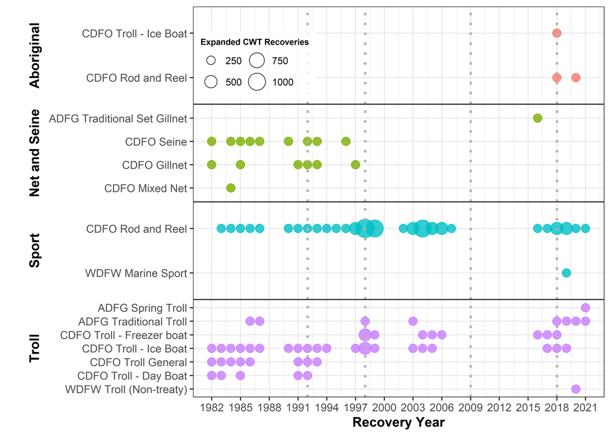

Figure 1.1: Expanded CWT recoveries of San Juan chinook in PSC fisheries over time. Fisheries along y axis are ordered from north to south within each Sector. Dashed gray lines indicate Pacific Salmon Treaty periods for reference. Data from MRP.

### 1.1.4 WCVI Recoveries